# Elected Female Representatives and their effect on Perception Women Leaders

Lisa Chu, Nida Haroon, Sophia Ahn, Victoria Ewing

March 19, 2019

# Introduction

In the United States, despite years of effort to increase the level of gender equality, women are underrepresented in leadership positions in the government and in business. In 2014, PEW Research Center conducted a nationally representative phone survey asking respondents how they felt about men and women in leadership positions. We hypothesize that being exposed to women in leadership positions will increase individuals’ perception of women as leaders.

Our research question is as follows: **“Does the percentage of female representatives in their state influence people’s perceptions of women as leaders?”.**

## Data

The data for the outcome variable is from the Gender and Leadership dataset from PEW Research Center. The final sample includes 1,835 adults, 18+ residing in the US and was conducted between November 12-21, 2014. The questionnaire was administered in both English and Spanish.

The data for the representatives is from the National Conference of State Legislatures. The two datasets were cleaned and merged to keep only the variables of interest.

The outcome variable is Question 5a on the PEW Survey which asks the respondents, ‘Which one of the following statements comes closest to your opinion about women as POLITICAL LEADERS?’ 1. Men generally make better political leaders than women 2. In general, women and men make equally good political leaders 3. Women generally make better political leaders than men

The outcome variable is an ordered categorical variable. We hypothesize that respondents’ gender, age, level of education, race, household income level, employment, political party and percentage of elect women representatives in respective States, all likely impact their perception of women as political leaders.

## Summary Statistics

To begin our analysis, we will examine the summary statistics for the variables in out data set.

```r
link='https://github.com/lmchu1/WomenLeaders599/raw/master/preprocessed_data.csv'

womendata<-read.csv(link,stringsAsFactors = F)

pander(names(womendata))
```

*age_group*, *educ_group*, *race*, *gender*, *hhincome_group*, *employment*, *party*, *opinion_leaders*, *state* and *perc_women*

```r
pander(summary(womendata))
```

Table continues below

| age_group | educ_group | race | gender |
| --- | --- | --- | --- |
| Min. :1.000 | Min. : 1.00 | Min. :1.000 | Min. :0.0000 |
| 1st Qu.:3.000 | 1st Qu.: 9.00 | 1st Qu.:1.000 | 1st Qu.:0.0000 |
| Median :4.000 | Median :10.00 | Median :1.000 | Median :1.0000 |
| Mean :4.043 | Mean :10.21 | Mean :1.623 | Mean :0.5016 |
| 3rd Qu.:5.000 | 3rd Qu.:12.00 | 3rd Qu.:2.000 | 3rd Qu.:1.0000 |
| Max. :7.000 | Max. :14.00 | Max. :5.000 | Max. :1.0000 |
| NA | NA | NA | NA |

Table continues below

| hhincome_group | employment | party | opinion_leaders |
| --- | --- | --- | --- |
| Min. : 1.0 | Min. :1.000 | Min. :1.000 | Min. :1.000 |
| 1st Qu.: 9.0 | 1st Qu.:1.000 | 1st Qu.:2.000 | 1st Qu.:2.000 |
| Median :13.0 | Median :2.000 | Median :5.000 | Median :2.000 |
| Mean :12.2 | Mean :2.945 | Mean :4.146 | Mean :1.949 |
| 3rd Qu.:16.0 | 3rd Qu.:5.000 | 3rd Qu.:6.000 | 3rd Qu.:2.000 |
| Max. :19.0 | Max. :7.000 | Max. :7.000 | Max. :3.000 |
| NA | NA | NA | NA’s :23 |

| state | perc_women |
| --- | --- |
| Length:1830 | Min. :0.1250 |
| Class :character | 1st Qu.:0.2000 |
| Mode :character | Median :0.2350 |
| NA | Mean :0.2402 |
| NA | 3rd Qu.:0.2670 |
| NA | Max. :0.4100 |
| NA | NA |

In the histogram below, we examine the distribution of “percent of female elected representatives” among the survey respondents. Because we are examining state legistures, all individuals from the same state have the same percent of female representatives. The percentage of female representatives in 2014 ranged from 12.5% to 41%.

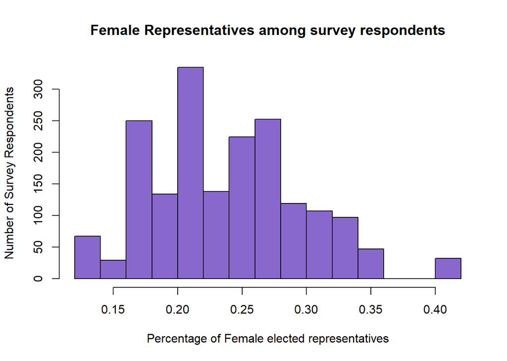

```r
hist(womendata$perc_women,
     xlab= 'Percentage of Female elected representatives' , ylab='Number of Survey Respondents',
     main='Female Representatives among survey respondents',
       col='mediumpurple3'
     )
```

The map of the United States shows that certain states have a much higher percentages of female representatives than others. For e.g. Colorado has 41% female representatives compared to Louisiana and South Carolina is 13%.

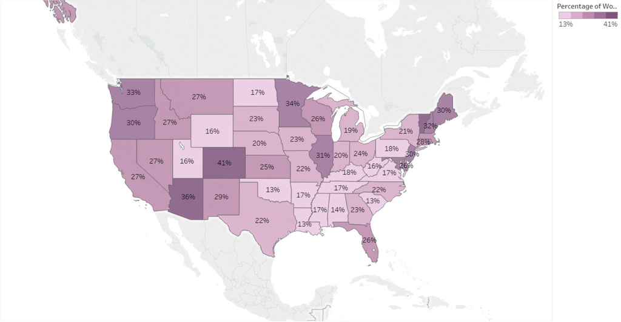

*Map of % of Female Representatives by State*

The bar chart below shows that the majority of respondents believe that women and men make equally good political leaders. However, a greater number believe that men make better political leaders than believe that women make better political leaders.

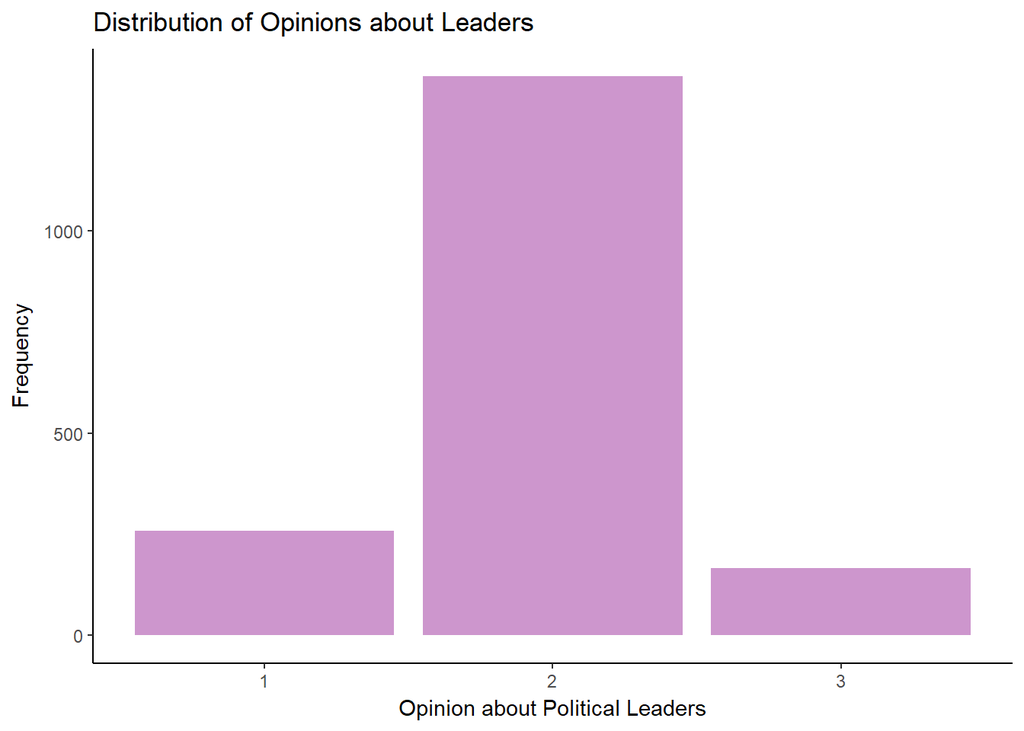

```r
ggplot(womendata, aes(opinion_leaders))+
       geom_bar(fill='plum3') + theme_classic() +
  xlab('Opinion about Political Leaders') + ylab('Frequency') + ggtitle('Distribution of Opinions about Leaders')
```

*Key:* 1. *Men generally make better political leaders than women* 2. *In general, women and men make equally good political leaders* 3. *Women generally make better political leaders than men*

We would also like to examine the average opinion about women as political leaders by different groups - gender, years of education, and political party. As the average increases, this indicates that the groups holds a higher opinion of women as leaders.

```r
womendataNA <- na.omit(womendata) #removes rows with missing data
gendermeans<-aggregate(womendataNA$opinion_leaders, list(womendataNA$gender), mean) #calculates the mean opinion about political leaders by gender
pander(gendermeans)
```

| Group.1 | x |
| --- | --- |
| 0 | 1.898 |
| 1 | 1.999 |

Here we can see that men (Group 0) have a lower opinion of women as leaders than do women, with an average of 1.898 vs 1.998.

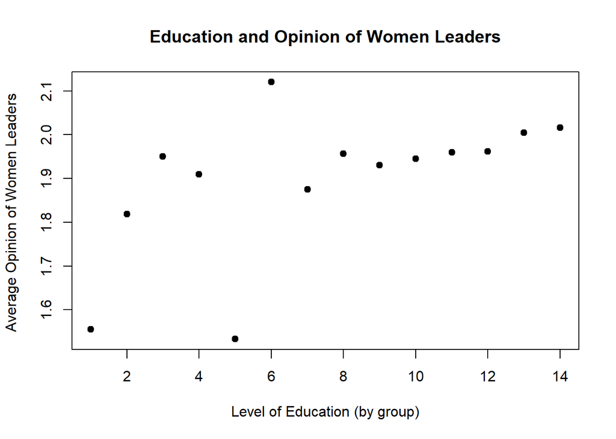

```r
educmeans<- aggregate(womendataNA$opinion_leaders, list(womendataNA$educ_group), mean) #calculates the mean opinion about political leaders by educational group
plot(educmeans$Group.1, educmeans$x, main="Education and Opinion of Women Leaders",
   xlab="Level of Education (by group)", ylab="Average Opinion of Women Leaders ", pch=19)
```

Generally, as education increases (represented by higher numbered education groups), opinion about women as leaders increases, though there is some variation.

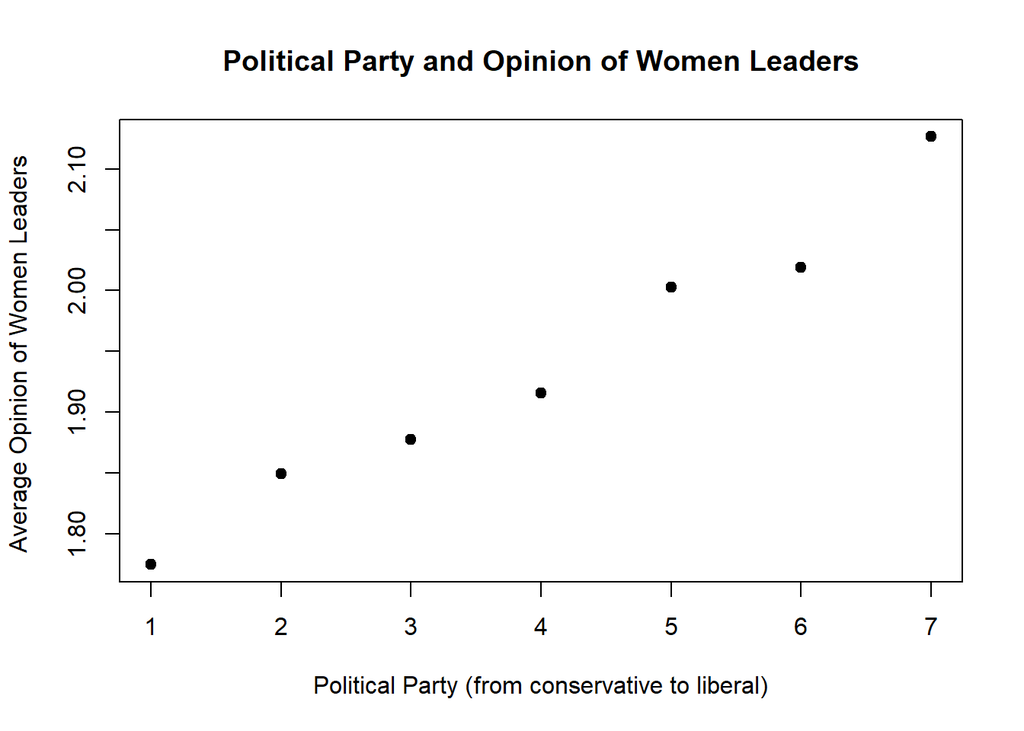

```r
partymeans<- aggregate(womendataNA$opinion_leaders, list(womendataNA$party), mean) #calculates the mean opinion about political leaders by political party
plot(partymeans$Group.1, partymeans$x, main="Political Party and Opinion of Women Leaders",
   xlab="Political Party (from conservative to liberal)", ylab="Average Opinion of Women Leaders ", pch=19)
```

Here we can see that as individuals identify as more liberal, their opinion of women as leaders increases.

# Application and Limitation of Linear Regression Model

The linear regression model we tested is as follows:

“Opinion of Leadersi =
$$\beta 0 + \beta 1 Percent_womenelected + \beta 2 age_group + \beta 3 hhincome_group + \beta 4 gender + \beta 5 educ_group + \beta6 race + \beta7 employment + \beta8party + ei"$$

```r
Linreg=lm(opinion_leaders ~ perc_women + age_group + hhincome_group + gender + educ_group + race + employment + party, data=womendata)
```

```r
pander(summary(Linreg))
```

|  | Estimate | Std. Error | t value | Pr(>\|t\|) |
| --- | --- | --- | --- | --- |
| **(Intercept)** | 1.416 | 0.08249 | 17.16 | 2.887e-61 |
| **perc_women** | 0.2262 | 0.1888 | 1.198 | 0.2312 |
| **age_group** | 0.007649 | 0.006789 | 1.127 | 0.26 |
| **hhincome_group** | 0.002045 | 0.002896 | 0.7059 | 0.4803 |
| **gender** | 0.09271 | 0.02221 | 4.174 | 3.142e-05 |
| **educ_group** | 0.01508 | 0.005778 | 2.61 | 0.009132 |
| **race** | -0.003688 | 0.009956 | -0.3704 | 0.7111 |
| **employment** | -0.001433 | 0.005455 | -0.2627 | 0.7928 |
| **party** | 0.05601 | 0.005327 | 10.51 | 3.906e-25 |

Fitting linear model: opinion_leaders ~ perc_women + age_group + hhincome_group + gender + educ_group + race + employment + party

| Observations | Residual Std. Error | $R^2$ | Adjusted $R^2$ |
| --- | --- | --- | --- |
| 1807 | 0.4655 | 0.07542 | 0.0713 |

A linear regression is not appropriate for this data because the outcome variable is an ordered categorical variable.

## QQPlot

The QQPlot below of the residuals is a good visual representation that the linear model is inappropriate.

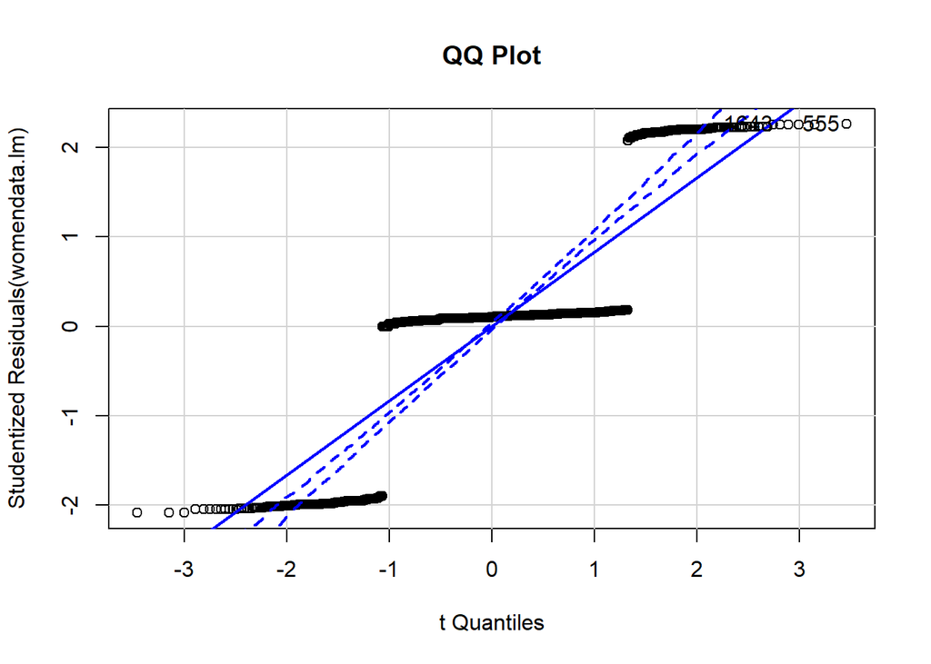

```
## [1]  555 1643
```

```r
womendata.lm=lm(opinion_leaders~perc_women, data=womendata)

qqPlot(womendata.lm, main="QQ Plot")
```

# Ordered Probit Model

Acknowledging the ordered nature of our outcome variable, we used an Ordered Probit Model for our study.

## Results

```r
results.oprob<-oglmx(opinion_leaders ~ perc_women + age_group + hhincome_group + gender + educ_group + race + employment + party, data=womendata, link="probit",
     constantMEAN = FALSE, constantSD = FALSE,
     delta=0,threshparam = NULL)

summary(results.oprob)
```

```
## Ordered Probit Regression
## Log-Likelihood: -1199.784
## No. Iterations: 5
## McFadden's R2: 0.05686781
## AIC: 2419.567
##                  Estimate Std. error t value  Pr(>|t|)
## perc_women      0.6085969  0.5114082  1.1900  0.234030
## age_group       0.0195693  0.0183527  1.0663  0.286293
## hhincome_group  0.0059706  0.0078528  0.7603  0.447066
## gender          0.2573429  0.0606006  4.2465 2.171e-05 ***
## educ_group      0.0415674  0.0156164  2.6618  0.007773 **
## race           -0.0104505  0.0269492 -0.3878  0.698175
## employment     -0.0033508  0.0148153 -0.2262  0.821068
## party           0.1551679  0.0150710 10.2958 < 2.2e-16 ***
## ----- Threshold Parameters -----
##                  Estimate Std. error t value Pr(>|t|)
## Threshold (1->2)  0.33490    0.22270  1.5038   0.1326
## Threshold (2->3)  2.88753    0.23444 12.3166   <2e-16 ***
## ---
## Signif. codes:  0 '***' 0.001 '**' 0.01 '*' 0.05 '.' 0.1 ' ' 1
```

As we are using the ordered probit model, we need to see the marginal effects to see the effect of our independent variables on our dependent variable.

```r
margins.oglmx(results.oprob,ascontinuous = TRUE)
```

```
## Marginal Effects on Pr(Outcome==1)
##                  Marg. Eff  Std. error  t value  Pr(>|t|)
## perc_women     -0.12752859  0.10720047  -1.1896  0.234193
## age_group      -0.00410065  0.00384745  -1.0658  0.286509
## hhincome_group -0.00125111  0.00164549  -0.7603  0.447060
## gender         -0.05392498  0.01272553  -4.2375  2.26e-05 ***
## educ_group     -0.00871026  0.00327502  -2.6596  0.007823 **
## race            0.00218985  0.00564696   0.3878  0.698169
## employment      0.00070215  0.00310451   0.2262  0.821070
## party          -0.03251470  0.00319896 -10.1641 < 2.2e-16 ***
## ------------------------------------
## Marginal Effects on Pr(Outcome==2)
##                  Marg. Eff  Std. error t value  Pr(>|t|)
## perc_women      0.03866715  0.03349801  1.1543  0.248372
## age_group       0.00124333  0.00119527  1.0402  0.298240
## hhincome_group  0.00037934  0.00050521  0.7509  0.452738
## gender          0.01635026  0.00515463  3.1720  0.001514 **
## educ_group      0.00264098  0.00113542  2.3260  0.020019 *
## race           -0.00066397  0.00171759 -0.3866  0.699073
## employment     -0.00021289  0.00094223 -0.2259  0.821244
## party           0.00985858  0.00228000  4.3239 1.533e-05 ***
## ------------------------------------
## Marginal Effects on Pr(Outcome==3)
##                  Marg. Eff  Std. error t value  Pr(>|t|)
## perc_women      0.08886144  0.07474558  1.1889  0.234498
## age_group       0.00285732  0.00268232  1.0652  0.286767
## hhincome_group  0.00087177  0.00114688  0.7601  0.447180
## gender          0.03757472  0.00894692  4.1997 2.672e-05 ***
## educ_group      0.00606927  0.00229097  2.6492  0.008068 **
## race           -0.00152588  0.00393528 -0.3877  0.698206
## employment     -0.00048925  0.00216339 -0.2262  0.821084
## party           0.02265612  0.00233710  9.6941 < 2.2e-16 ***
## ---
## Signif. codes:  0 '***' 0.001 '**' 0.01 '*' 0.05 '.' 0.1 ' ' 1
```

Our results show that education, gender, and party have significant effects at the 95% confidence level on a person’s opinions on political leaders.

Regarding our primary variable of interest, an 1-unit increase in the percentage of elected women representatives in the respondent’s state of residence insignificantly decreases the likelihood of believing that men generally make better political leaders than woman by roughly 12%.

## Heteroskedasticity

```r
results.oprobhet<-oglmx(opinion_leaders ~ perc_women + educ_group + age_group + gender + hhincome_group + race + employment + party, data=womendata,constantMEAN= FALSE, constantSD= FALSE,threshparam=NULL)

summary(results.oprobhet)
```

```
## Ordered Probit Regression
## Log-Likelihood: -1199.784
## No. Iterations: 8
## McFadden's R2: 0.05686779
## AIC: 2421.567
## ----- Mean Equation ------
##                   Estimate  Std. error t value Pr(>|t|)
## perc_women      0.05476202  0.14356680  0.3814   0.7029
## educ_group      0.00374486  0.00941437  0.3978   0.6908
## age_group       0.00176239  0.00468166  0.3764   0.7066
## gender          0.02321212  0.05802437  0.4000   0.6891
## hhincome_group  0.00053825  0.00151466  0.3554   0.7223
## race           -0.00094716  0.00339418 -0.2791   0.7802
## employment     -0.00030404  0.00153812 -0.1977   0.8433
## party           0.01399701  0.03486226  0.4015   0.6881
## ----- SD Equation ------
##                  Estimate Std. error t value Pr(>|t|)
## Threshold (1->2)  -2.4055     2.4892 -0.9664   0.3339
## ----- Threshold Parameters -----
##                  Estimate Std. error t value Pr(>|t|)
## Threshold (2->3) 0.030090   0.077248  0.3895   0.6969
## NA               0.260369   0.648098  0.4017   0.6879
```

```r
results.oprobhet<-oglmx(opinion_leaders ~ perc_women + educ_group + age_group + gender + hhincome_group + race + employment + party, data=womendata,constantMEAN= FALSE, constantSD= FALSE,threshparam=NULL)

summary(results.oprobhet$Hetero)
```

```
##    Mode   FALSE
## logical       1
```

We tested our model for heteroskedasticity to see if the error term has constant variance. Because our test resulted in “FALSE,” we know that there is equal variance in the distribution of residuals.

## Multi-collinearity

```r
pander(vif(Linreg) > 8 )
```

Table continues below

| perc_women | age_group | hhincome_group | gender | educ_group | race |
| --- | --- | --- | --- | --- | --- |
| FALSE | FALSE | FALSE | FALSE | FALSE | FALSE |

| employment | party |
| --- | --- |
| FALSE | FALSE |

We tested for multicollinearity to see if our independent variables are perfect linear functions of each other. If there is multicollinearity, then our model will not work because we cannot simultaneously get estimates for independent variable that are perfect linear functions. Fortunately, our test resulted in “false” for all variables.

Confirming that our results do not show heteroskedasticity and multicollinearity further strengthen the statistical theory and validity of our results.

## Conclusion

Our study shows that elected women representatives in states does not have a signficant effect on their opinion about women assuming leadership roles in politics. The lack of effect is not necessarily surprising, as there is likely some endogeneity between the two variables - while exposure to women in leadership positions may come to think more highly of women as leaders, people who think highly of women as leaders are also more likely to elect them. However, we found that being female, having a higher education level, and identifying as a liberal/Democrat increases the likelikihood of believing that women make better political leaders.